# Incarceration Visualizations

Creasa

2/15/2021

## Data Description

The most recent year in the data is 2018 which is three years ago, thus the data may not be as relevant since the most recent presidential administration now is different from that in 2018, and policies may have changed. Specifically, on January 26, 2021, President Joe Biden signed a series of executive orders in the name of advancing racial equity. One of the most high-profile orders resurrected an Obama-era policy to phase out the Department of Justice’s contracts with privately managed prisons.Biden’s executive order impacts a segment of the current carceral state.

## Incarceration Trends Over Time

Here is a plot for Incarceration Over Time.

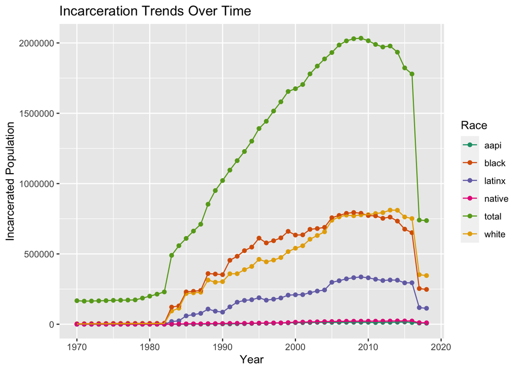

## Highest Black Incarceration Rates

Here is a bar chart for states with the Highest Black Incarceration Rates (top-10).

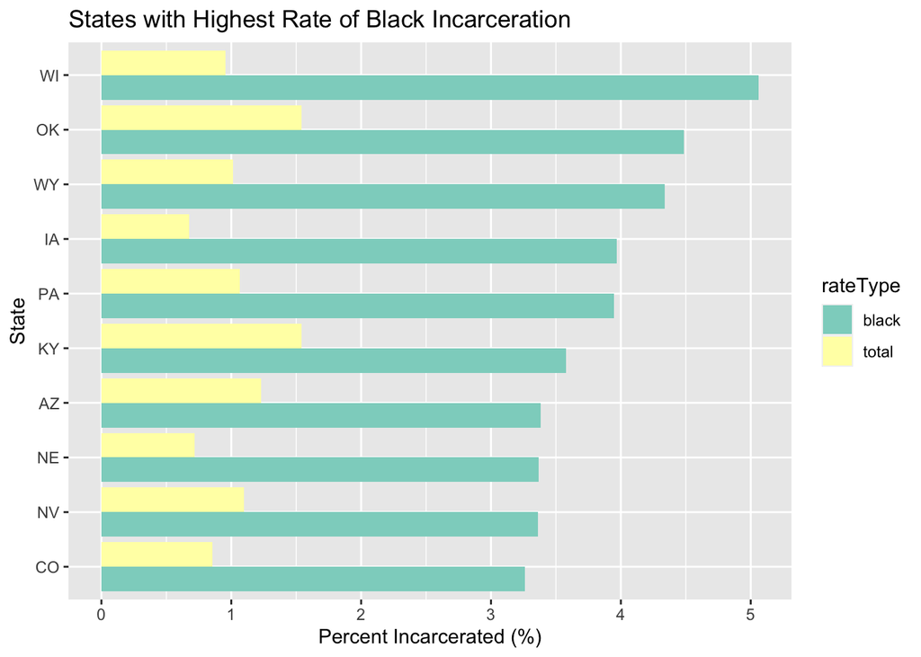

Observing the chart, I notice the following about the state-level incarceration rates are similar across the state (especially the top-ten).Howeverm,all black rate significantly higher than the total rate in that state.The missing thing is that there is no proportion of black population in total population in each state.

## Racial Incarceration Discrepancy Map

Here is a map for Racial Incarceration Discrepancy (Specifically, for the black population in Washington state in year 2016).

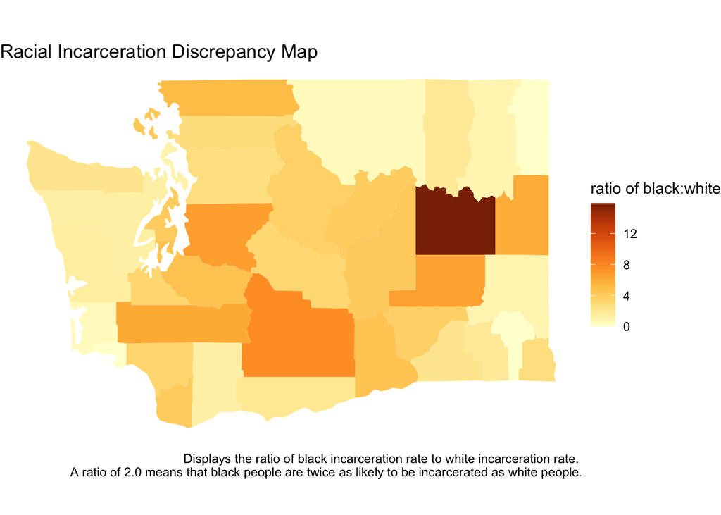

## Your Own Visualization

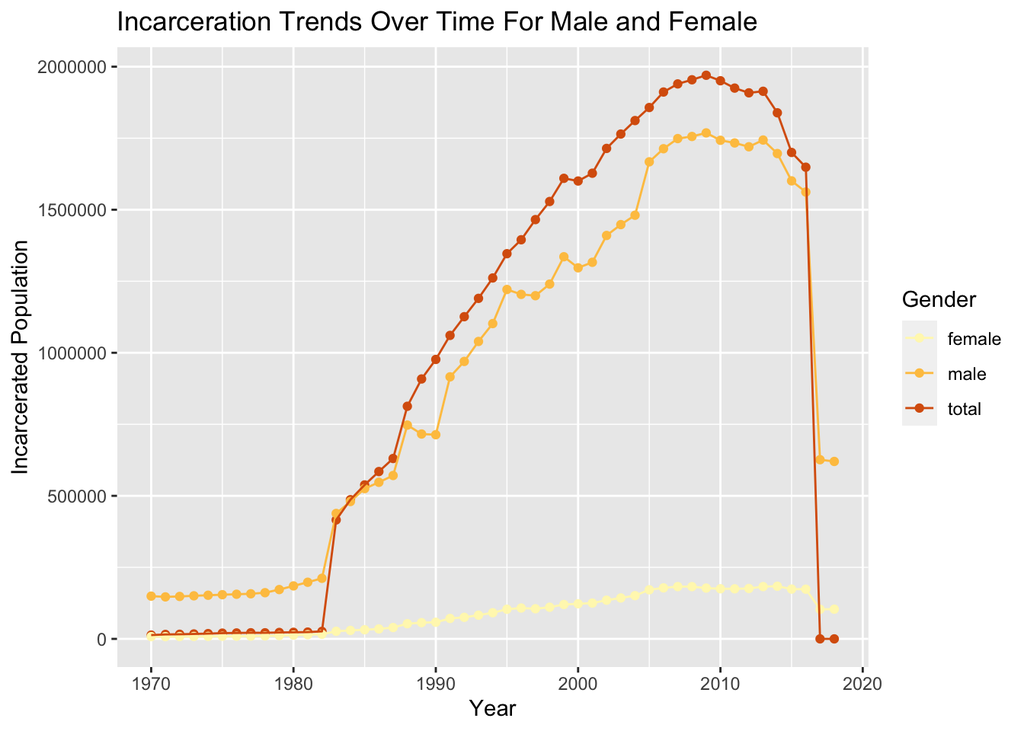

### The questions my visualization attempt to answer?

How does the female incarceration population changed over time? Are the incarceration trends over time different for Male and for Female?

From my visualization, I notice a gradual increase in the female incarcerated population starting from 1983, becoming constant since 2005 but there is a decrease in 2017. Also, over the past 50 years, Male incarcerated population is significantly higher than female incarcerated population, with much sharper increase. Though more male are in prison than female, the rate of growth for female imprisonment has been twice as high as that of men since 1980. There are 1.2 million women under the supervision of the criminal justice system.That is the reason why I want to explore this visual layout,because I really care about the gender discrimination.The plot with colored lines show trends over time clearly, enabling us to compare and investigate the incarceration rate for female and male directly.